# Statistical inference with the GSS data

## Setup

### Load packages

```r
library(ggplot2)
library(dplyr)
library(statsr)
library(tidyr)
library(purrr)
library(gt)
```

### Load data

Make sure your data and R Markdown files are in the same directory. When loaded your data file will be called `gss`. Delete this note when before you submit your work.

```r
load("gss.Rdata")
```

## Part 1: Data

From the [GSS codebook Appendix A](https://gss.norc.org/content/dam/gss/get-documentation/pdf/codebook/GSS_Codebook_AppendixA.pdf), for the 1977+ surveys, the General Social Survey has been using a **full probability sample**. 1972 through 1974 surveys used a modified probability sample, which introduces the quota element at the block level. The 1975 and 1976 studies were conducted with a transitional sample design, viz., one-half full probability and one-half block quota. From the [GSS codebook Appendix B](https://gss.norc.org/content/dam/gss/get-documentation/pdf/codebook/GSS_Codebook_AppendixB.pdf), the data in this survey are collected through interviews, where interviewers answer questionnaires.

Since the data is collected through random sampling of the population instead of random assignment, the conclusions we draw from the sample is **generalizable to the population**, but we **cannot conclude casual relations** between the explanatory variable and response variable in our study.

## Part 2: Research question

**Research question 1: Public Opinion on Education Spending in the US** In this question, I want to investigate the shift in public opinion on education spending in the US over time, more specifically, opinion on the amount of money spent on improving the nation’s education system. I want to answer the following three sub-questions:

1.1. What is the proportion of people in the US population who think they’re spending too little money on improving the nation’s education system in year 1972 - 2012, respectively?

1.2. Has the proportion of people who think they’re spending too little money on education increased from year 1972 to year 2012?

1.3. Is there a relationship between education level and the opinion on education spending in the U.S. in year 2012?

## Part 3: Exploratory data analysis

After loading the data, we can see in the data viewer that the data has 57061 rows, each corresponding to a respondent, and 114 variables. We can refer to the codebook for what the variables represent.

There’re 29 years in total in our data:

```r
gss %>% pull(year) %>% unique()
```

```
##  [1] 1972 1973 1974 1975 1976 1977 1978 1980 1982 1983 1984 1985 1986 1987 1988
## [16] 1989 1990 1991 1993 1994 1996 1998 2000 2002 2004 2006 2008 2010 2012
```

We’ll work on the research question 1.1. Let’s first extract the data that is relevant to this question, which is the variable “year” and “nateduc”, and put it into a new dataframe.

```r
educ <- gss %>%
  select(year, nateduc)
```

Let’s look at the “nateduc” variable:

```r
class(educ$nateduc)
```

```
## [1] "factor"
```

```r
educ %>% pull(nateduc) %>% unique()
```

```
## [1] <NA>        Too Little  About Right Too Much
## Levels: Too Little About Right Too Much
```

```r
summary(educ$nateduc)
```

```
##  Too Little About Right    Too Much        NA's
##       20619        9374        2262       24806
```

We can see that the variable “nateduc” is factor type (categorical) with 3 levels, and there’re 24806 missing values in the dataset represented by NA. We’ll remove rows that contain missing values:

```r
nrow_raw <- nrow(educ)
educ <- na.omit(educ)
print(sprintf("Removed %d rows.", nrow_raw - nrow(educ)))
```

```
## [1] "Removed 24806 rows."
```

```r
educ %>% pull(year) %>% unique()
```

```
##  [1] 1973 1974 1975 1976 1977 1978 1980 1982 1983 1984 1985 1986 1987 1988 1989
## [16] 1990 1991 1993 1994 1996 1998 2000 2002 2004 2006 2008 2010 2012
```

We can see that in year 1972 the data on this variable is missing, which means this question might not have been asked this year. We’ll continue our study on the remaining 28 years where data on this variable is present.

The proportion of people who think they’re spending “Too Little” on education each year in descending order is:

```r
educ %>%
  group_by(year) %>%
  summarize(little_prop = sum(nateduc == "Too Little") / n()) %>%
  arrange(desc(little_prop))
```

```
## # A tibble: 28 × 2
##     year little_prop
##    <int>       <dbl>
##  1  2012       0.744
##  2  2002       0.739
##  3  2006       0.735
##  4  1990       0.731
##  5  2004       0.724
##  6  2010       0.721
##  7  1994       0.721
##  8  2000       0.720
##  9  2008       0.712
## 10  1998       0.710
## # ℹ 18 more rows
```

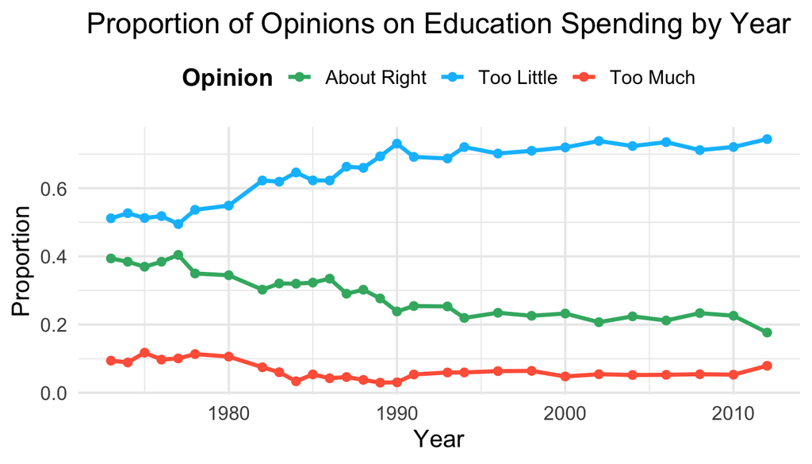

```r
# Calculate the proportion of each category by year
educ_prop_year <- educ %>%
  group_by(year) %>%
  summarize(
    little_prop = sum(nateduc == "Too Little") / n(),
    much_prop = sum(nateduc == "Too Much") / n(),
    about_right_prop = sum(nateduc == "About Right") / n()
  )

# Define colors that are consistent and visually distinguishable
color_scheme <- c("Too Little" = "deepskyblue", "Too Much" = "tomato", "About Right" = "mediumseagreen")

# Create the plot
ggplot(data = educ_prop_year) +
  geom_line(aes(x = year, y = little_prop, color = "Too Little"), size = 1.2) +
  geom_point(aes(x = year, y = little_prop, color = "Too Little"), size = 2.2) +
  geom_line(aes(x = year, y = much_prop, color = "Too Much"), size = 1.2) +
  geom_point(aes(x = year, y = much_prop, color = "Too Much"), size = 2.2) +
  geom_line(aes(x = year, y = about_right_prop, color = "About Right"), size = 1.2) +
  geom_point(aes(x = year, y = about_right_prop, color = "About Right"), size = 2.2) +
  scale_color_manual(values = color_scheme) +  # Apply the color scheme
  labs(
    title = "Proportion of Opinions on Education Spending by Year",
    x = "Year",
    y = "Proportion",
    color = "Opinion"
  ) +
  theme_minimal(base_size = 15) +
  theme(
    legend.position = "top",
    plot.title = element_text(hjust = 0.5),
    legend.title = element_text(face = "bold")
  )
```

We can also visualize this change with standardized stacked barplot for proportions of the three opinions over years:

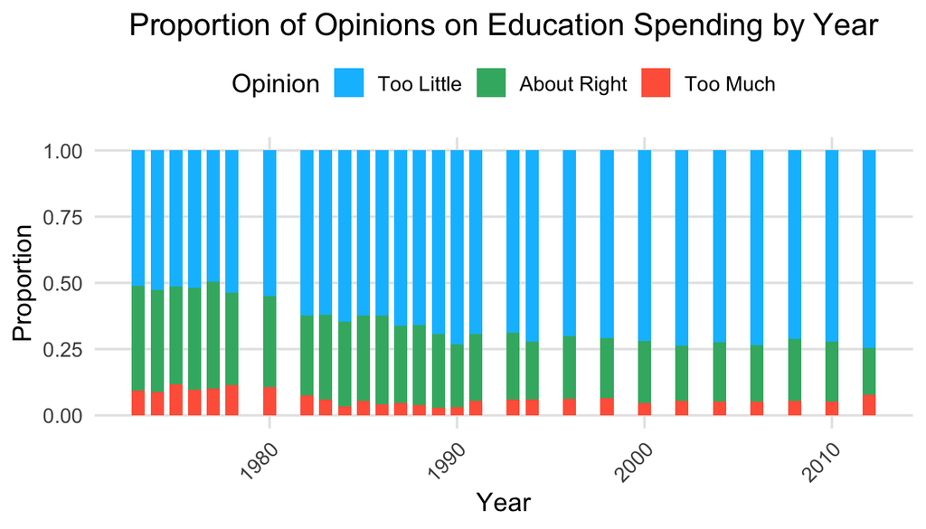

```r
# Create a styled stacked bar plot with proportions
ggplot(educ) +
  aes(x = year, fill = nateduc) +
  geom_bar(position = "fill", width = 0.7) +
  scale_fill_manual(values = c("Too Little" = "deepskyblue",
                                "About Right" = "mediumseagreen",
                                "Too Much" = "tomato")) +
  labs(x = "Year", y = "Proportion", fill = "Opinion",
       title = "Proportion of Opinions on Education Spending by Year") +
  theme_minimal(base_size = 14) +
  theme(legend.position = "top",
        panel.grid.major = element_line(color = "gray90"),
        panel.grid.minor = element_blank(),
        axis.text.x = element_text(angle = 45, hjust = 1),
        plot.title = element_text(hjust = 0.5))  # Center the title
```

## Part 4: Inference

We will now study our first sub question by performing inference for a single proportion. We’ll work on the proportion of people who think they’re spending “Too Little” on education in year 1973 in detail, then apply the same analysis for the other years.

We’ll compute the 95% confidence interval for the population proportion of people who think they’re spending “Too Little” in year 1973 using the Central Limit Theorem. First, let’s check the conditions for applying the CLT:

1. *Independence*: as discussed in the **Data** section, the data is collected from random sampling. Sample size n = 1434, which is smaller than 10% of the US population in year 1973. Therefore, we can assume the samples are independent of each other.

```r
educ %>%
  filter(year == 1973) %>%
  summarize(n())
```

```
##    n()
## 1 1434
```

2. *Sample size/skew*: in the sample for year 1973, there’re 734 success cases (“Too Little”) and 700 failures (other opinions), which satisfies the condition of 10 successes/failures.

```r
educ %>%
  filter(year == 1973) %>%
  summarize(n_suc = sum(nateduc == "Too Little"), n_fail = n() - n_suc)
```

```
##   n_suc n_fail
## 1   734    700
```

The conditions are met. By CLT, the confidence interval for a population proportion is

$$\hat{p} \pm z^\star \sqrt{\frac{\hat{p}(1-\hat{p})}{n}}$$

```r
educ_1973 <- educ %>%
  filter(year == 1973) %>%
  mutate(opinion = ifelse(nateduc == "Too Little", "Too Little", "other"))

inference(y = opinion, data = educ_1973, statistic = "proportion", type = "ci", method = "theoretical", success = "Too Little")
```

```
## Single categorical variable, success: Too Little
## n = 1434, p-hat = 0.5119
## 95% CI: (0.486 , 0.5377)
```

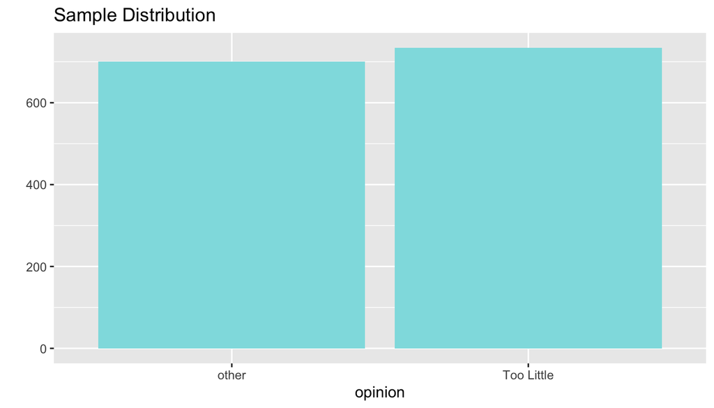

We are 95% confident that the population proportion of people who think they’re spending “Too Little” on education in the US in year 1973 is between 48.6% to 53.8%. That is to say, if we take the random sample of size n = 1434 repetitively and compute the confidence interval, 95% the times the CI would capture the true population proportion.

Let’s use `nest` and `inference` to compute the 95% confidence interval for years 1973 - 2012.

```r
# Make a new binary categorical variable "opinion"
educ <- educ %>%
  mutate(opinion = ifelse(nateduc == "Too Little", "Too Little", "other"))

# Group by year and nest the data
ci_prop_little <- educ %>%
  group_by(year) %>%
  nest() %>%
  mutate(ci_data = map(data, ~ {
    suppressMessages(suppressWarnings({
      inf_output <- inference(y = opinion, data = ., statistic ="proportion", type = "ci", method = "theoretical", success = "Too Little", verbose = FALSE)
      c(lower = inf_output[[3]][1], upper = inf_output[[3]][2])
      }))
    })) %>%
  unnest_wider(ci_data) %>%  # Expand `ci_data` into `lower` and `upper` columns
  mutate(p_hat = (lower + upper) / 2) %>%  # Calculate `p_hat`
  select(year, p_hat, lower, upper)
```

Let’s plot the confidence interval of the population proportion of people who think they’re spending “Too Little” on education in year 1973 - 2012:

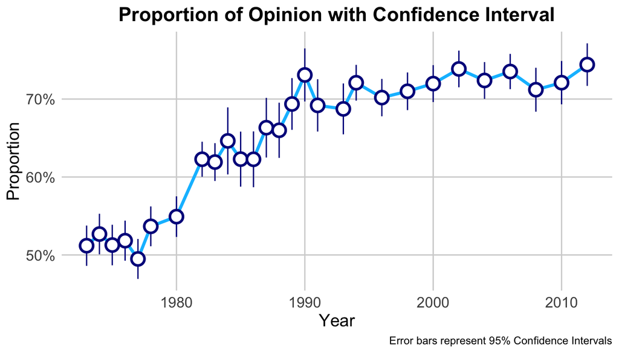

```r
ggplot(ci_prop_little, aes(x = year, y = p_hat)) +
  geom_line(color = "deepskyblue", size = 1.2) +  # Thicker blue line for better visibility
  geom_pointrange(aes(ymin = lower, ymax = upper),
                  color = "darkblue",
                  size = 1,
                  shape = 21,
                  fill = "white", # White fill for points
                  stroke = 1.5) +  # Thicker border around points
  labs(title = "Proportion of Opinion with Confidence Interval",
       x = "Year",
       y = "Proportion",
       caption = "Error bars represent 95% Confidence Intervals") +
  theme_minimal() +  # Minimal theme for a clean look
  theme(
    plot.title = element_text(hjust = 0.5, size = 16, face = "bold"),  # Center title with larger font
    axis.title.x = element_text(size = 14),  # Larger x-axis title
    axis.title.y = element_text(size = 14),  # Larger y-axis title
    axis.text = element_text(size = 12),  # Larger axis text
    panel.grid.minor = element_blank(),  # Remove minor grid lines for a cleaner look
    panel.grid.major = element_line(color = "lightgrey")  # Light color for major grid lines
  ) +
  scale_y_continuous(labels = scales::percent)
```

This plot shows the change in the proportion of people who think they’re spending “Too Little” on education in the US population. We’re 95% confident that the actual proportion falls within the confidence interval. This plot shows a clear upward trend in the proportion, taking the error in the estimation into consideration.

So far we have answered research question 1.1, let’s work on question 1.2. From the plot above, we can see that the proportion of underfunded education has increased between year 1973 and 2012. To answer this question with more certainty, we’ll perform a hypothesis test for comparing two independent proportions at 5% significance level.

**The hypotheses**

$$H_0: p_1 = p_2 \\
H_A: p_2 > p_1$$

**Check conditions**

*(1) Independence*

Within groups: In year 1973 and 2012, both samples are obtained with random sampling from the population. In both years, the sample size is smaller than 10% of the US population of that year.

Between groups: The 1973 and 2012 sample are independence of each other.

```r
educ %>%
  filter(year == 2012) %>%
  summarize(n())
```

```
##   n()
## 1 985
```

Therefore, we can assume the independence condition is met.

*(2) Sample size/skew*

Previously we checked the success-failure condition for year 1973 is met. Let’s check for year 2012 with the same method:

```r
educ %>%
  filter(year == 2012) %>%
  summarize(n_suc = sum(nateduc == "Too Little"), n_fail = n() - n_suc)
```

```
##   n_suc n_fail
## 1   733    252
```

in the sample for year 2012, there’re 733 success cases and 252 failures, which satisfies the condition of 10 successes/failures.

Let’s perform the hypothesis test with `inference`:

```r
ht_data <- educ %>%
  filter(year %in% c(1973, 2012))

inference(y = opinion, x = year, data = ht_data, statistic = "proportion", type = "ht", alternative = 'less', method = "theoretical", success = "Too Little")
```

```
## Response variable: categorical (2 levels, success: Too Little)
## Explanatory variable: categorical (2 levels)
## n_1973 = 1434, p_hat_1973 = 0.5119
## n_2012 = 985, p_hat_2012 = 0.7442
## H0: p_1973 =  p_2012
## HA: p_1973 < p_2012
## z = -11.4905
## p_value = < 0.0001
```

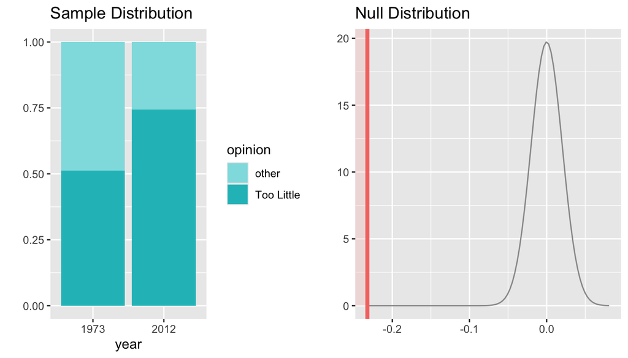

The result shows that the p-value is smaller than 0.0001, which is smaller than our significance level 0.05. Therefore we reject the null hypothesis. The data provide convincing evidence for the alternative hypothesis, aka, the proportion of people who think they’re spending “Too Little” on education in the US population has increased from year 1973 to year 2012.

Let’s filter the data that is relevant to question 1.3 to a new dataframe.

```r
deg_educ <- gss %>%
  filter(year == 2012) %>%
  select(degree, nateduc)
```

Let’s look at the “degree” variable:

```r
class(deg_educ$degree)
```

```
## [1] "factor"
```

```r
deg_educ %>% pull(degree) %>% unique()
```

```
## [1] Bachelor       High School    Junior College Lt High School Graduate
## [6] <NA>
## Levels: Lt High School High School Junior College Bachelor Graduate
```

```r
summary(deg_educ$degree)
```

```
## Lt High School    High School Junior College       Bachelor       Graduate
##            280            976            151            354            205
##           NA's
##              8
```

We can see that the variable “degree” is factor type (categorical) with 5 levels, and there’re 8 missing values in the dataset represented by NA. We’ll remove rows that contain missing values:

```r
nrow_raw <- nrow(deg_educ)
deg_educ <- na.omit(deg_educ)
print(sprintf("Removed %d rows.", nrow_raw - nrow(deg_educ)))
```

```
## [1] "Removed 991 rows."
```

To find out whether the education level, which is the respondent’s highest degree, is related to the respondent’s opinion on national spending on education, we’ll perform a $\chi$-square independence test for these two categorical variables.

Let’s first summarize our data into a two-way table:

```r
# Create the two-way table
data_table <- table(deg_educ$nateduc, deg_educ$degree)

# Add totals
data_table_total <- addmargins(data_table)
```

```r
# Print the table
gt_table <- as.data.frame.matrix(data_table_total)

gt_table %>%
 gt(rownames_to_stub = TRUE) %>%
    tab_header(title = "Opinion on Education Spending by Highest Degree") %>%
  tab_options(
    table.font.size = 12,
    table.font.color = "black",
    table.background.color = "white",
    column_labels.font.weight = "bold"
  )
```

Opinion on Education Spending by Highest Degree

|  | Lt High School | High School | Junior College | Bachelor | Graduate | Sum |
| --- | --- | --- | --- | --- | --- | --- |
| Too Little | 81 | 371 | 62 | 134 | 84 | 732 |
| About Right | 48 | 80 | 16 | 18 | 11 | 173 |
| Too Much | 7 | 34 | 8 | 20 | 9 | 78 |
| Sum | 136 | 485 | 86 | 172 | 104 | 983 |

Let’s create a standardized stacked barplot to visually represent the data:

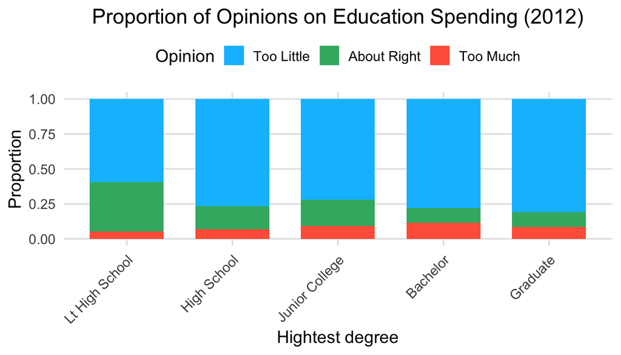

```r
# Create a styled stacked bar plot with proportions
ggplot(deg_educ) +
  aes(x = degree, fill = nateduc) +
  geom_bar(position = "fill", width = 0.7) +
  scale_fill_manual(values = c("Too Little" = "deepskyblue",
                                "About Right" = "mediumseagreen",
                                "Too Much" = "tomato")) +
  labs(x = "Hightest degree", y = "Proportion", fill = "Opinion",
       title = "Proportion of Opinions on Education Spending (2012)") +
  theme_minimal(base_size = 14) +
  theme(legend.position = "top",
        panel.grid.major = element_line(color = "gray90"),
        panel.grid.minor = element_blank(),
        axis.text.x = element_text(angle = 45, hjust = 1),
        plot.title = element_text(hjust = 0.5))  # Center the title
```

Let’s perform the $\chi$-square independence test.

**The hypotheses**

$H_0$: the opinion on education spending and education level (represented by the respondent’s highest degree) in year 2012 are independent. $H_A$: the opinion on education spending and education level (represented by the respondent’s highest degree) in year 2012 are dependent.

**Check conditions**

*(1) Independence*

As discussed in the **Data** section, the data is collected from random sampling. From the two-way table, each entry is smaller than 10% of the US population. Each case can only enter one cell in the table. Therefore, we can assume the samples are independent of each other.

*(2) Sample size*

As shown in the expected count table at the end of this analysis, each cell have >5 expected cases. The expected count it calculated by:

$$\text{expected count} = \frac{(\text{row total}) \times (\text{column
total})}{\text{table total}}$$

The conditions are met, we can now perform the $\chi$-square test:

```r
chisq_stat <- chisq.test(data_table)

chisq_stat
```

```
##
##  Pearson's Chi-squared test
##
## data:  data_table
## X-squared = 42.771, df = 8, p-value = 9.701e-07
```

The test statistic is 42.8, and the p-value is smaller than 0.01. Therefore, we can reject the null hypothesis. We’re 99% confident that the opinion on education spending and education level in year 2012 are dependent.

The expected count is given by:

```r
chisq_stat$expected
```

```
##
##               Lt High School High School Junior College  Bachelor  Graduate
##   Too Little       101.27365   361.15972      64.040692 128.08138 77.444557
##   About Right       23.93489    85.35605      15.135300  30.27060 18.303154
##   Too Much          10.79145    38.48423       6.824008  13.64802  8.252289
```